# UG_data_analysis1

Ke

2018-01-15

variables in the models: - Reappraisal Direction - total stake - Fairness score - clinical groups - education - IncomePerCapita - EXIT (4 missing values) - trial number (within block number) - block number - an impulsivity measure: BIS_NONPLAN (3 missing values)/UPPS negative urgency - an interpersonal function measure: IIP15INTAMBV (4 missing values)

# Whether HLM is needed?

## Intercept only

$$Accept\,Offer = 1$$

```
## [1] "logit"
```

```
##
## =============================================
##                       Dependent variable:
##                   ---------------------------
##                           AcceptOffer
## ---------------------------------------------
## Constant                   0.656***
##                             (0.021)
##
## ---------------------------------------------
## Observations                10,088
## Log Likelihood            -6,477.375
## Akaike Inf. Crit.         12,956.750
## =============================================
## Note:             *p<0.1; **p<0.05; ***p<0.01
```

```
## [1] "probability"
```

```
##
## ===========
## (Intercept)
## -----------
##    0.658
## -----------
```

## Null model: random intercept only

$$Accept\,Offer = 1 + (1|ID)$$

```
## [1] "logit coefficients"
```

```
##
## ===============================================
##                         Dependent variable:
##                     ---------------------------
##                             AcceptOffer
## -----------------------------------------------
## Constant                     0.836***
##                               (0.102)
##
## -----------------------------------------------
## Observations                  10,088
## Log Likelihood              -5,871.774
## Akaike Inf. Crit.           11,747.550
## Bayesian Inf. Crit.         11,761.990
## ===============================================
## Note:               *p<0.1; **p<0.05; ***p<0.01
```

```
## [1] "probability coefficients"
```

```
##   probability
## 1   0.6976155
```

By adding the ID (nested), the AIC (1|D) is smaller than the AIC (1). So HLM is necessary.

The variance of the intercept in the *null model is 1.157*. That is the variance can’t be explained by the random effect of ID. Compare the variance with more complicated models. If the intercept variance gets smaller, that is an indication of the additional predictors adding more explanation to the DV.

## Intraclass Correlation (ICC)

Test if HLM is needed: whether there is variation over the level 2 variable (participant ID). If the ICC > 0, then HLM is needed.

```
## ICC is 0.5365138
```

The ICC > 0, the HLM is needed.

# correlation matrix of the subject level variables

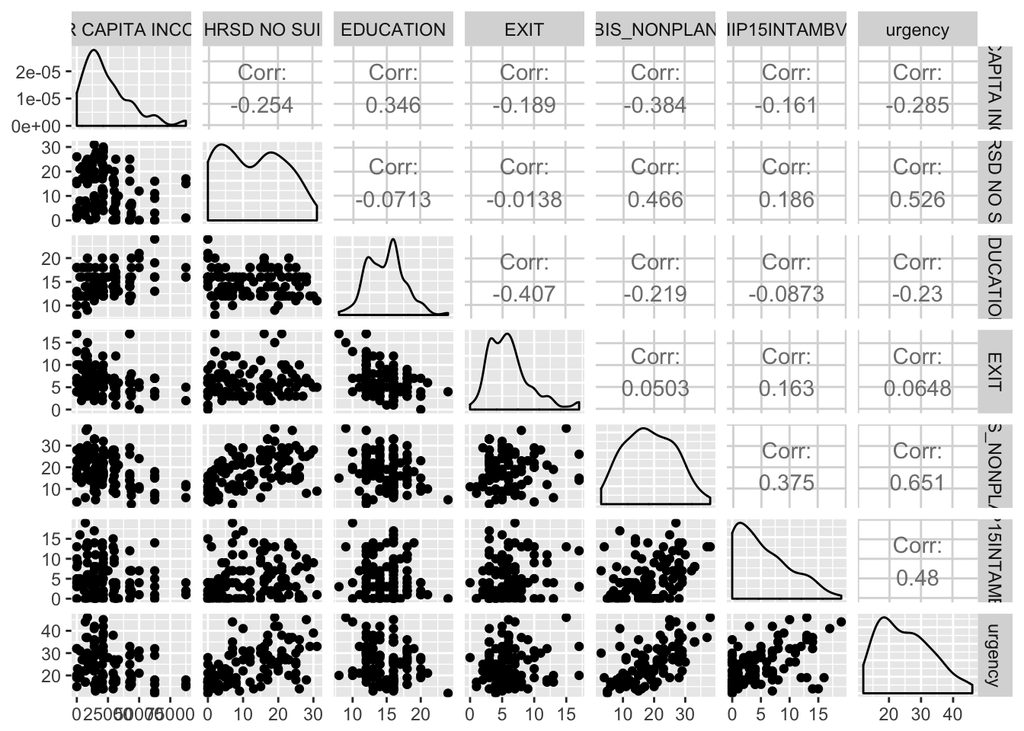

The following variables are moderately/highly correlated: DRS x income, **education x income**, **EXIT x education**, **BIS nonplan x income**, BIS nonplan x HSD, **interpersonal x BIS nonplan**, urgency x HSD, urgency x BIS nonplan, **urgency x interpersonal**.

# Level 1 model (Random intercept and fixed slopes with random effect (1|ID))

## No interaction model

$$Accept\,Offer = Reappraisal\,Direction + scale(total\,Stake) + Fairness\,score + (1|ID)$$

```
## [1] "logit coefficients"
```

```
##
## =======================================================
##                                 Dependent variable:
##                             ---------------------------
##                                     AcceptOffer
## -------------------------------------------------------
## ReappraisalDirectionempathy          2.238***
##                                       (0.074)
##
## ReappraisalDirectionpunish           -1.051***
##                                       (0.059)
##
## scale(totalStake)                      0.034
##                                       (0.025)
##
## Fairness_score2                       -0.177
##                                       (0.130)
##
## Fairness_score3                      -0.887***
##                                       (0.114)
##
## Fairness_score4                      -1.992***
##                                       (0.114)
##
## Fairness_score5                      -2.567***
##                                       (0.115)
##
## Constant                             2.326***
##                                       (0.183)
##
## -------------------------------------------------------
## Observations                          12,740
## Log Likelihood                      -5,449.298
## Akaike Inf. Crit.                   10,916.590
## Bayesian Inf. Crit.                 10,983.670
## =======================================================
## Note:                       *p<0.1; **p<0.05; ***p<0.01
```

```
## [1] "probability coefficients"
```

```
##                             probability
## (Intercept)                   0.9109944
## ReappraisalDirectionempathy   0.9036522
## ReappraisalDirectionpunish    0.2590189
## scale(totalStake)             0.5085680
## Fairness_score2               0.4559524
## Fairness_score3               0.2916322
## Fairness_score4               0.1200855
## Fairness_score5               0.0713073
```

# Level 1 model with $group$ predictor (random effect (1|ID))

## No interaction effect

The model with 4 groups and 5 groups:
$$Accept\,Offer = Reappraisal\,Direction + totalStake + Fairness\,score + group4 + (1|ID)$$

```
## [1] "model with 4 groups"
```

```
##
## =======================================================
##                                 Dependent variable:
##                             ---------------------------
##                                     AcceptOffer
## -------------------------------------------------------
## ReappraisalDirectionempathy          2.238***
##                                       (0.074)
##
## ReappraisalDirectionpunish           -1.051***
##                                       (0.059)
##
## scale(totalStake)                      0.034
##                                       (0.025)
##
## Fairness_score2                       -0.177
##                                       (0.130)
##
## Fairness_score3                      -0.887***
##                                       (0.114)
##
## Fairness_score4                      -1.991***
##                                       (0.114)
##
## Fairness_score5                      -2.567***
##                                       (0.115)
##
## group4attempter                       -0.234
##                                       (0.374)
##
## group4depression                       0.642
##                                       (0.414)
##
## group4ideator                          0.293
##                                       (0.429)
##
## Constant                             2.204***
##                                       (0.299)
##
## -------------------------------------------------------
## Observations                          12,740
## Log Likelihood                      -5,446.670
## Akaike Inf. Crit.                   10,917.340
## Bayesian Inf. Crit.                 11,006.770
## =======================================================
## Note:                       *p<0.1; **p<0.05; ***p<0.01
```

```
## [1] "probability coefficients"
```

```
##                             probability
## (Intercept)                  0.90064923
## ReappraisalDirectionempathy  0.90360619
## ReappraisalDirectionpunish   0.25899134
## scale(totalStake)            0.50856677
## Fairness_score2              0.45596500
## Fairness_score3              0.29166694
## Fairness_score4              0.12010626
## Fairness_score5              0.07131654
## group4attempter              0.44188785
## group4depression             0.65519874
## group4ideator                0.57284002
```

```
## [1] "model with 5 groups"
```

```
##
## =======================================================
##                                 Dependent variable:
##                             ---------------------------
##                                     AcceptOffer
## -------------------------------------------------------
## ReappraisalDirectionempathy          2.238***
##                                       (0.074)
##
## ReappraisalDirectionpunish           -1.051***
##                                       (0.059)
##
## scale(totalStake)                      0.034
##                                       (0.025)
##
## Fairness_score2                       -0.177
##                                       (0.130)
##
## Fairness_score3                      -0.887***
##                                       (0.114)
##
## Fairness_score4                      -1.991***
##                                       (0.114)
##
## Fairness_score5                      -2.567***
##                                       (0.115)
##
## group5AttempterHL                     -0.273
##                                       (0.452)
##
## group5AttempterLL                     -0.196
##                                       (0.446)
##
## group5depression                       0.642
##                                       (0.414)
##
## group5ideator                          0.293
##                                       (0.428)
##
## Constant                             2.205***
##                                       (0.299)
##
## -------------------------------------------------------
## Observations                          12,740
## Log Likelihood                      -5,446.658
## Akaike Inf. Crit.                   10,919.320
## Bayesian Inf. Crit.                 11,016.200
## =======================================================
## Note:                       *p<0.1; **p<0.05; ***p<0.01
```

```
## [1] "probability coefficients"
```

```
##                             probability
## (Intercept)                  0.90065559
## ReappraisalDirectionempathy  0.90360071
## ReappraisalDirectionpunish   0.25898448
## scale(totalStake)            0.50856646
## Fairness_score2              0.45596416
## Fairness_score3              0.29166806
## Fairness_score4              0.12010666
## Fairness_score5              0.07131647
## group5AttempterHL            0.43225756
## group5AttempterLL            0.45108849
## group5depression             0.65517762
## group5ideator                0.57283041
```

Clinically groups are not significantly different from HC in terms of gamble acceptance.

### The model with an individual subject level variable

$$Accept\,Offer = Reappraisal\,Direction + scale(total\,Stake) + Fairness\,score + group4 + VAR + (1|ID)$$

```
## [1] "Education"
```

```
##
## =======================================================
##                                 Dependent variable:
##                             ---------------------------
##                                     AcceptOffer
## -------------------------------------------------------
## ReappraisalDirectionempathy          2.238***
##                                       (0.074)
##
## ReappraisalDirectionpunish           -1.051***
##                                       (0.059)
##
## scale(totalStake)                      0.034
##                                       (0.025)
##
## Fairness_score2                       -0.177
##                                       (0.130)
##
## Fairness_score3                      -0.887***
##                                       (0.114)
##
## Fairness_score4                      -1.991***
##                                       (0.114)
##
## Fairness_score5                      -2.567***
##                                       (0.115)
##
## group4attempter                       -0.129
##                                       (0.387)
##
## group4depression                       0.661
##                                       (0.413)
##
## group4ideator                          0.323
##                                       (0.428)
##
## scale(EDUCATION)                       0.135
##                                       (0.135)
##
## Constant                             2.177***
##                                       (0.299)
##
## -------------------------------------------------------
## Observations                          12,740
## Log Likelihood                      -5,446.171
## Akaike Inf. Crit.                   10,918.340
## Bayesian Inf. Crit.                 11,015.230
## =======================================================
## Note:                       *p<0.1; **p<0.05; ***p<0.01
```

```
## [1] "probability coefficients"
```

```
##                             probability
## (Intercept)                  0.89817141
## ReappraisalDirectionempathy  0.90361838
## ReappraisalDirectionpunish   0.25901153
## scale(totalStake)            0.50856700
## Fairness_score2              0.45596331
## Fairness_score3              0.29166141
## Fairness_score4              0.12009990
## Fairness_score5              0.07131269
## group4attempter              0.46788119
## group4depression             0.65942578
## group4ideator                0.58006359
## scale(EDUCATION)             0.53378159
```

```
## [1] "income"
```

```
##
## =======================================================
##                                 Dependent variable:
##                             ---------------------------
##                                     AcceptOffer
## -------------------------------------------------------
## ReappraisalDirectionempathy          2.238***
##                                       (0.074)
##
## ReappraisalDirectionpunish           -1.051***
##                                       (0.059)
##
## scale(totalStake)                      0.034
##                                       (0.025)
##
## Fairness_score2                       -0.177
##                                       (0.130)
##
## Fairness_score3                      -0.887***
##                                       (0.114)
##
## Fairness_score4                      -1.991***
##                                       (0.114)
##
## Fairness_score5                      -2.567***
##                                       (0.115)
##
## group4attempter                       -0.185
##                                       (0.396)
##
## group4depression                       0.671
##                                       (0.422)
##
## group4ideator                          0.330
##                                       (0.439)
##
## scale(IncomePerCapita)                 0.051
##                                       (0.138)
##
## Constant                             2.170***
##                                       (0.313)
##
## -------------------------------------------------------
## Observations                          12,740
## Log Likelihood                      -5,446.602
## Akaike Inf. Crit.                   10,919.200
## Bayesian Inf. Crit.                 11,016.090
## =======================================================
## Note:                       *p<0.1; **p<0.05; ***p<0.01
```

```
## [1] "probability coefficients"
```

```
##                             probability
## (Intercept)                  0.89754503
## ReappraisalDirectionempathy  0.90359049
## ReappraisalDirectionpunish   0.25896918
## scale(totalStake)            0.50856637
## Fairness_score2              0.45596669
## Fairness_score3              0.29167231
## Fairness_score4              0.12010743
## Fairness_score5              0.07131646
## group4attempter              0.45392859
## group4depression             0.66178148
## group4ideator                0.58171609
## scale(IncomePerCapita)       0.51269140
```

```
## [1] "EXIT"
```

```
##
## =======================================================
##                                 Dependent variable:
##                             ---------------------------
##                                     AcceptOffer
## -------------------------------------------------------
## ReappraisalDirectionempathy          2.238***
##                                       (0.074)
##
## ReappraisalDirectionpunish           -1.051***
##                                       (0.059)
##
## scale(totalStake)                      0.034
##                                       (0.025)
##
## Fairness_score2                       -0.177
##                                       (0.130)
##
## Fairness_score3                      -0.888***
##                                       (0.114)
##
## Fairness_score4                      -1.992***
##                                       (0.114)
##
## Fairness_score5                      -2.567***
##                                       (0.115)
##
## group4attempter                       -0.058
##                                       (0.376)
##
## group4depression                       0.612
##                                       (0.406)
##
## group4ideator                          0.354
##                                       (0.421)
##
## scale(EXIT)                          -0.273**
##                                       (0.136)
##
## Constant                             2.204***
##                                       (0.294)
##
## -------------------------------------------------------
## Observations                          12,740
## Log Likelihood                      -5,444.691
## Akaike Inf. Crit.                   10,915.380
## Bayesian Inf. Crit.                 11,012.260
## =======================================================
## Note:                       *p<0.1; **p<0.05; ***p<0.01
```

```
## [1] "probability coefficients"
```

```
##                             probability
## (Intercept)                  0.90056367
## ReappraisalDirectionempathy  0.90365063
## ReappraisalDirectionpunish   0.25898403
## scale(totalStake)            0.50856561
## Fairness_score2              0.45594667
## Fairness_score3              0.29160638
## Fairness_score4              0.12006712
## Fairness_score5              0.07130031
## group4attempter              0.48542974
## group4depression             0.64836027
## group4ideator                0.58768407
## scale(EXIT)                  0.43211429
```

```
## [1] "MMSE"
```

```
##
## =======================================================
##                                 Dependent variable:
##                             ---------------------------
##                                     AcceptOffer
## -------------------------------------------------------
## ReappraisalDirectionempathy          2.238***
##                                       (0.074)
##
## ReappraisalDirectionpunish           -1.051***
##                                       (0.059)
##
## scale(totalStake)                      0.034
##                                       (0.025)
##
## Fairness_score2                       -0.177
##                                       (0.130)
##
## Fairness_score3                      -0.887***
##                                       (0.114)
##
## Fairness_score4                      -1.992***
##                                       (0.114)
##
## Fairness_score5                      -2.567***
##                                       (0.115)
##
## group4attempter                       -0.072
##                                       (0.388)
##
## group4depression                       0.671
##                                       (0.411)
##
## group4ideator                          0.335
##                                       (0.426)
##
## scale(MMSE)                            0.176
##                                       (0.128)
##
## Constant                             2.153***
##                                       (0.299)
##
## -------------------------------------------------------
## Observations                          12,740
## Log Likelihood                      -5,445.744
## Akaike Inf. Crit.                   10,917.490
## Bayesian Inf. Crit.                 11,014.370
## =======================================================
## Note:                       *p<0.1; **p<0.05; ***p<0.01
```

```
## [1] "probability coefficients"
```

```
##                             probability
## (Intercept)                  0.89593189
## ReappraisalDirectionempathy  0.90363303
## ReappraisalDirectionpunish   0.25902166
## scale(totalStake)            0.50856620
## Fairness_score2              0.45595826
## Fairness_score3              0.29164449
## Fairness_score4              0.12008971
## Fairness_score5              0.07130887
## group4attempter              0.48192721
## group4depression             0.66177340
## group4ideator                0.58293953
## scale(MMSE)                  0.54377366
```

```
## [1] "UPPSP NEG URGENCY"
```

```
##
## =======================================================
##                                 Dependent variable:
##                             ---------------------------
##                                     AcceptOffer
## -------------------------------------------------------
## ReappraisalDirectionempathy          2.238***
##                                       (0.074)
##
## ReappraisalDirectionpunish           -1.051***
##                                       (0.059)
##
## scale(totalStake)                      0.034
##                                       (0.025)
##
## Fairness_score2                       -0.177
##                                       (0.130)
##
## Fairness_score3                      -0.887***
##                                       (0.114)
##
## Fairness_score4                      -1.992***
##                                       (0.114)
##
## Fairness_score5                      -2.567***
##                                       (0.115)
##
## group4attempter                        0.023
##                                       (0.433)
##
## group4depression                      0.804*
##                                       (0.435)
##
## group4ideator                          0.495
##                                       (0.461)
##
## scale(urgency)                        -0.194
##                                       (0.168)
##
## Constant                             1.994***
##                                       (0.349)
##
## -------------------------------------------------------
## Observations                          12,740
## Log Likelihood                      -5,446.008
## Akaike Inf. Crit.                   10,918.020
## Bayesian Inf. Crit.                 11,014.900
## =======================================================
## Note:                       *p<0.1; **p<0.05; ***p<0.01
```

```
## [1] "probability coefficients"
```

```
##                             probability
## (Intercept)                  0.88012458
## ReappraisalDirectionempathy  0.90363433
## ReappraisalDirectionpunish   0.25902276
## scale(totalStake)            0.50856814
## Fairness_score2              0.45596135
## Fairness_score3              0.29165650
## Fairness_score4              0.12009797
## Fairness_score5              0.07131221
## group4attempter              0.50573137
## group4depression             0.69081524
## group4ideator                0.62128752
## scale(urgency)               0.45158524
```

```
## [1] "IIP15INTAMBV, interpersonal"
```

```
##
## =======================================================
##                                 Dependent variable:
##                             ---------------------------
##                                     AcceptOffer
## -------------------------------------------------------
## ReappraisalDirectionempathy          2.238***
##                                       (0.074)
##
## ReappraisalDirectionpunish           -1.052***
##                                       (0.059)
##
## scale(totalStake)                      0.034
##                                       (0.025)
##
## Fairness_score2                       -0.177
##                                       (0.130)
##
## Fairness_score3                      -0.887***
##                                       (0.114)
##
## Fairness_score4                      -1.991***
##                                       (0.114)
##
## Fairness_score5                      -2.567***
##                                       (0.115)
##
## group4attempter                       -0.117
##                                       (0.387)
##
## group4depression                      0.697*
##                                       (0.415)
##
## group4ideator                          0.395
##                                       (0.437)
##
## scale(IIP15INTAMBV)                   -0.145
##                                       (0.136)
##
## Constant                             2.117***
##                                       (0.309)
##
## -------------------------------------------------------
## Observations                          12,740
## Log Likelihood                      -5,446.103
## Akaike Inf. Crit.                   10,918.210
## Bayesian Inf. Crit.                 11,015.090
## =======================================================
## Note:                       *p<0.1; **p<0.05; ***p<0.01
```

```
## [1] "probability coefficients"
```

```
##                             probability
## (Intercept)                  0.89251091
## ReappraisalDirectionempathy  0.90359051
## ReappraisalDirectionpunish   0.25891961
## scale(totalStake)            0.50856982
## Fairness_score2              0.45596397
## Fairness_score3              0.29166281
## Fairness_score4              0.12010385
## Fairness_score5              0.07131546
## group4attempter              0.47082238
## group4depression             0.66747851
## group4ideator                0.59754041
## scale(IIP15INTAMBV)          0.46375472
```

```
## [1] "nonplan"
```

```
##
## =======================================================
##                                 Dependent variable:
##                             ---------------------------
##                                     AcceptOffer
## -------------------------------------------------------
## ReappraisalDirectionempathy          2.238***
##                                       (0.074)
##
## ReappraisalDirectionpunish           -1.051***
##                                       (0.059)
##
## scale(totalStake)                      0.034
##                                       (0.025)
##
## Fairness_score2                       -0.177
##                                       (0.130)
##
## Fairness_score3                      -0.887***
##                                       (0.114)
##
## Fairness_score4                      -1.991***
##                                       (0.114)
##
## Fairness_score5                      -2.567***
##                                       (0.115)
##
## group4attempter                        0.005
##                                       (0.426)
##
## group4depression                      0.815*
##                                       (0.439)
##
## group4ideator                          0.470
##                                       (0.454)
##
## scale(BIS_NONPLAN)                    -0.222
##                                       (0.195)
##
## Constant                             1.978***
##                                       (0.358)
##
## -------------------------------------------------------
## Observations                          12,740
## Log Likelihood                      -5,446.029
## Akaike Inf. Crit.                   10,918.060
## Bayesian Inf. Crit.                 11,014.940
## =======================================================
## Note:                       *p<0.1; **p<0.05; ***p<0.01
```

```
## [1] "probability coefficients"
```

```
##                             probability
## (Intercept)                  0.87842911
## ReappraisalDirectionempathy  0.90359347
## ReappraisalDirectionpunish   0.25896904
## scale(totalStake)            0.50856611
## Fairness_score2              0.45596569
## Fairness_score3              0.29166960
## Fairness_score4              0.12010291
## Fairness_score5              0.07131338
## group4attempter              0.50115831
## group4depression             0.69324994
## group4ideator                0.61536470
## scale(BIS_NONPLAN)           0.44476097
```

$EXIT$ is the only subject level variable has significant influence on the gamble acceptance.

## Interaction effect models

Fit specific interaction models. From higher order to lower.

$$Accept\,Offer = Reappraisal\,Direction + scale(total\,Stake) + Fairness\,score + group4 + INTERACTION + (1|ID)$$

1. $Reappraisal\,Direction$ x $scale(total\,Stake)$ x $Fairness\,score$ x $group4$ four way interaction effect, and see if the model is significant. If not, drop this interaction.

It failed to converge at 4 way interaction

2. $ReappraisalDirection$ x $Fairness_score$ x $group4$ three way interaction

It failed to converge.

3. $Reappraisal\,Direction$ x $scale(total\,Stake)$ x $group4$ three way interaction

```
##
## ==========================================================================================
##                                                                    Dependent variable:
##                                                                ---------------------------
##                                                                        AcceptOffer
## ------------------------------------------------------------------------------------------
## ReappraisalDirectionempathy                                             2.059***
##                                                                          (0.150)
##
## ReappraisalDirectionpunish                                              -1.201***
##                                                                          (0.129)
##
## scale(totalStake)                                                        -0.163*
##                                                                          (0.089)
##
## Fairness_score2                                                          -0.252*
##                                                                          (0.131)
##
## Fairness_score3                                                         -0.895***
##                                                                          (0.114)
##
## Fairness_score4                                                         -2.062***
##                                                                          (0.114)
##
## Fairness_score5                                                         -2.626***
##                                                                          (0.115)
##
## group4attempter                                                           0.143
##                                                                          (0.394)
##
## group4depression                                                          0.059
##                                                                          (0.433)
##
## group4ideator                                                             0.324
##                                                                          (0.455)
##
## ReappraisalDirectionempathy:scale(totalStake)                            -0.081
##                                                                          (0.135)
##
## ReappraisalDirectionpunish:scale(totalStake)                             0.251**
```

[output cut: 42 more lines]

```
##                                                                          (0.228)
##
## ReappraisalDirectionpunish:scale(totalStake):group4ideator                0.227
##                                                                          (0.196)
##
## Constant                                                                2.366***
##                                                                          (0.312)
##
## ------------------------------------------------------------------------------------------
## Observations                                                             12,740
## Log Likelihood                                                         -5,322.116
## Akaike Inf. Crit.                                                      10,702.230
## Bayesian Inf. Crit.                                                    10,918.350
## ==========================================================================================
## Note:                                                          *p<0.1; **p<0.05; ***p<0.01
```

```
## [1] "probability coefficients"
```

```
##                                                                probability
## (Intercept)                                                     0.91417810
## ReappraisalDirectionempathy                                     0.88687507
## ReappraisalDirectionpunish                                      0.23132221
## scale(totalStake)                                               0.45933918
## Fairness_score2                                                 0.43736368
## Fairness_score3                                                 0.29005159
## Fairness_score4                                                 0.11285209
## Fairness_score5                                                 0.06748712
## group4attempter                                                 0.53571266
## group4depression                                                0.51478750
## group4ideator                                                   0.58037481
## ReappraisalDirectionempathy:scale(totalStake)                   0.47966752
## ReappraisalDirectionpunish:scale(totalStake)                    0.56248104
## ReappraisalDirectionempathy:group4attempter                     0.28594453
## ReappraisalDirectionpunish:group4attempter                      0.40162010
## ReappraisalDirectionempathy:group4depression                    0.80707921
## ReappraisalDirectionpunish:group4depression                     0.68368142
## ReappraisalDirectionempathy:group4ideator                       0.52293835
## ReappraisalDirectionpunish:group4ideator                        0.47484974
## scale(totalStake):group4attempter                               0.51884397
## scale(totalStake):group4depression                              0.47968442
## scale(totalStake):group4ideator                                 0.49241462
## ReappraisalDirectionempathy:scale(totalStake):group4attempter   0.59140104
## ReappraisalDirectionpunish:scale(totalStake):group4attempter    0.52138136
## ReappraisalDirectionempathy:scale(totalStake):group4depression  0.56046385
## ReappraisalDirectionpunish:scale(totalStake):group4depression   0.57424932
## ReappraisalDirectionempathy:scale(totalStake):group4ideator     0.56399782
## ReappraisalDirectionpunish:scale(totalStake):group4ideator      0.55648275
```

$Reappraisal\,Direction$ x $scale(total\,Stake)$ x $group4$ has weak significant influence on gamble acceptance.

4. $fairness\, score$ x $group4$ two way interaction

```
##
## ============================================================
##                                      Dependent variable:
##                                  ---------------------------
##                                          AcceptOffer
## ------------------------------------------------------------
## ReappraisalDirectionempathy               2.269***
##                                            (0.074)
##
## ReappraisalDirectionpunish                -1.058***
##                                            (0.059)
##
## scale(totalStake)                           0.034
##                                            (0.026)
##
## Fairness_score2                            -0.337
##                                            (0.284)
##
## Fairness_score3                           -1.194***
##                                            (0.249)
##
## Fairness_score4                           -2.428***
##                                            (0.248)
##
## Fairness_score5                           -3.291***
##                                            (0.250)
##
## group4attempter                             0.190
##                                            (0.504)
##
## group4depression                           -0.494
##                                            (0.498)
##
## group4ideator                              -0.099
##                                            (0.562)
##
## Fairness_score2:group4attempter           -0.865**
##                                            (0.408)
##
## Fairness_score3:group4attempter            -0.628*
```

[output cut: 27 more lines]

```
##                                            (0.395)
##
## Fairness_score5:group4ideator               0.406
##                                            (0.396)
##
## Constant                                  2.654***
##                                            (0.363)
##
## ------------------------------------------------------------
## Observations                               12,740
## Log Likelihood                           -5,391.625
## Akaike Inf. Crit.                        10,831.250
## Bayesian Inf. Crit.                      11,010.110
## ============================================================
## Note:                            *p<0.1; **p<0.05; ***p<0.01
```

```
## [1] "probability coefficients"
```

```
##                                  probability
## (Intercept)                       0.93426616
## ReappraisalDirectionempathy       0.90628880
## ReappraisalDirectionpunish        0.25764202
## scale(totalStake)                 0.50860064
## Fairness_score2                   0.41644204
## Fairness_score3                   0.23250159
## Fairness_score4                   0.08104522
## Fairness_score5                   0.03587247
## group4attempter                   0.54729182
## group4depression                  0.37899530
## group4ideator                     0.47516822
## Fairness_score2:group4attempter   0.29627305
## Fairness_score3:group4attempter   0.34807599
## Fairness_score4:group4attempter   0.43120253
## Fairness_score5:group4attempter   0.41318210
## Fairness_score2:group4depression  0.65373884
## Fairness_score3:group4depression  0.69611590
## Fairness_score4:group4depression  0.73533637
## Fairness_score5:group4depression  0.85485942
## Fairness_score2:group4ideator     0.64684265
## Fairness_score3:group4ideator     0.64961216
## Fairness_score4:group4ideator     0.56368085
## Fairness_score5:group4ideator     0.60008242
```

Fairness score and group has significant interaction.

5. $reappraisal\, direction$ x $group4$ two way interaction

```
##
## ========================================================================
##                                                  Dependent variable:
##                                              ---------------------------
##                                                      AcceptOffer
## ------------------------------------------------------------------------
## scale(totalStake)                                       0.035
##                                                        (0.026)
##
## Fairness_score2                                        -0.176
##                                                        (0.131)
##
## Fairness_score3                                       -0.890***
##                                                        (0.114)
##
## Fairness_score4                                       -2.007***
##                                                        (0.114)
##
## Fairness_score5                                       -2.597***
##                                                        (0.115)
##
## ReappraisalDirectionempathy                           2.094***
##                                                        (0.149)
##
## ReappraisalDirectionpunish                            -1.180***
##                                                        (0.128)
##
## group4attempter                                         0.148
##                                                        (0.392)
##
## group4depression                                        0.054
##                                                        (0.430)
##
## group4ideator                                           0.317
##                                                        (0.451)
##
## ReappraisalDirectionempathy:group4attempter           -0.972***
##                                                        (0.192)
##
## ReappraisalDirectionpunish:group4attempter            -0.394**
```

[output cut: 9 more lines]

```
##                                                        (0.247)
##
## ReappraisalDirectionpunish:group4ideator               -0.086
##                                                        (0.204)
##
## Constant                                              2.313***
##                                                        (0.310)
##
## ------------------------------------------------------------------------
## Observations                                           12,740
## Log Likelihood                                       -5,357.968
## Akaike Inf. Crit.                                    10,751.940
## Bayesian Inf. Crit.                                  10,886.080
## ========================================================================
## Note:                                        *p<0.1; **p<0.05; ***p<0.01
```

```
## [1] "probability coefficients"
```

```
##                                              probability
## (Intercept)                                   0.90991484
## scale(totalStake)                             0.50887317
## Fairness_score2                               0.45599495
## Fairness_score3                               0.29120912
## Fairness_score4                               0.11849918
## Fairness_score5                               0.06931631
## ReappraisalDirectionempathy                   0.89034119
## ReappraisalDirectionpunish                    0.23513444
## group4attempter                               0.53689850
## group4depression                              0.51344756
## group4ideator                                 0.57858451
## ReappraisalDirectionempathy:group4attempter   0.27443285
## ReappraisalDirectionpunish:group4attempter    0.40276728
## ReappraisalDirectionempathy:group4depression  0.80497478
## ReappraisalDirectionpunish:group4depression   0.68461521
## ReappraisalDirectionempathy:group4ideator     0.52044458
## ReappraisalDirectionpunish:group4ideator      0.47854629
```

reappraisal direction x group4 has significant interaction.

6. $fairness\, score$ x $group4$ two way interaction

```
##
## ============================================================
##                                      Dependent variable:
##                                  ---------------------------
##                                          AcceptOffer
## ------------------------------------------------------------
## scale(totalStake)                           0.034
##                                            (0.026)
##
## ReappraisalDirectionempathy               2.269***
##                                            (0.074)
##
## ReappraisalDirectionpunish                -1.058***
##                                            (0.059)
##
## Fairness_score2                            -0.337
##                                            (0.285)
##
## Fairness_score3                           -1.194***
##                                            (0.249)
##
## Fairness_score4                           -2.428***
##                                            (0.248)
##
## Fairness_score5                           -3.291***
##                                            (0.250)
##
## group4attempter                             0.190
##                                            (0.504)
##
## group4depression                           -0.494
##                                            (0.498)
##
## group4ideator                              -0.099
##                                            (0.563)
##
## Fairness_score2:group4attempter           -0.865**
##                                            (0.408)
##
## Fairness_score3:group4attempter            -0.628*
```

[output cut: 27 more lines]

```
##                                            (0.395)
##
## Fairness_score5:group4ideator               0.406
##                                            (0.397)
##
## Constant                                  2.654***
##                                            (0.363)
##
## ------------------------------------------------------------
## Observations                               12,740
## Log Likelihood                           -5,391.625
## Akaike Inf. Crit.                        10,831.250
## Bayesian Inf. Crit.                      11,010.110
## ============================================================
## Note:                            *p<0.1; **p<0.05; ***p<0.01
```

```
## [1] "probability coefficients"
```

```
##                                  probability
## (Intercept)                       0.93426648
## scale(totalStake)                 0.50860046
## ReappraisalDirectionempathy       0.90628876
## ReappraisalDirectionpunish        0.25764194
## Fairness_score2                   0.41644584
## Fairness_score3                   0.23250060
## Fairness_score4                   0.08104548
## Fairness_score5                   0.03587260
## group4attempter                   0.54730620
## group4depression                  0.37900307
## group4ideator                     0.47515864
## Fairness_score2:group4attempter   0.29625647
## Fairness_score3:group4attempter   0.34806406
## Fairness_score4:group4attempter   0.43118783
## Fairness_score5:group4attempter   0.41316764
## Fairness_score2:group4depression  0.65373341
## Fairness_score3:group4depression  0.69611605
## Fairness_score4:group4depression  0.73533384
## Fairness_score5:group4depression  0.85485786
## Fairness_score2:group4ideator     0.64684335
## Fairness_score3:group4ideator     0.64961986
## Fairness_score4:group4ideator     0.56368610
## Fairness_score5:group4ideator     0.60008643
```

fairness score x group4 has significant interaction.

7. $total\, stake$ x $group4$ two way interaction

```
##
## ==============================================================
##                                        Dependent variable:
##                                    ---------------------------
##                                            AcceptOffer
## --------------------------------------------------------------
## scale(totalStake)                            -0.087*
##                                              (0.053)
##
## ReappraisalDirectionempathy                 2.241***
##                                              (0.074)
##
## ReappraisalDirectionpunish                  -1.052***
##                                              (0.059)
##
## Fairness_score2                              -0.176
##                                              (0.131)
##
## Fairness_score3                             -0.888***
##                                              (0.114)
##
## Fairness_score4                             -1.994***
##                                              (0.114)
##
## Fairness_score5                             -2.571***
##                                              (0.115)
##
## group4attempter                              -0.236
##                                              (0.375)
##
## group4depression                              0.640
##                                              (0.415)
##
## group4ideator                                 0.292
##                                              (0.430)
##
## scale(totalStake):group4attempter           0.229***
##                                              (0.070)
##
## scale(totalStake):group4depression           0.117*
##                                              (0.067)
##
## scale(totalStake):group4ideator               0.117
##                                              (0.085)
##
## Constant                                    2.209***
##                                              (0.300)
##
## --------------------------------------------------------------
## Observations                                 12,740
## Log Likelihood                             -5,441.396
## Akaike Inf. Crit.                          10,912.790
## Bayesian Inf. Crit.                        11,024.580
## ==============================================================
## Note:                              *p<0.1; **p<0.05; ***p<0.01
```

```
## [1] "probability coefficients"
```

```
##                                    probability
## (Intercept)                         0.90103396
## scale(totalStake)                   0.47828715
## ReappraisalDirectionempathy         0.90384427
## ReappraisalDirectionpunish          0.25888779
## Fairness_score2                     0.45621339
## Fairness_score3                     0.29142911
## Fairness_score4                     0.11982011
## Fairness_score5                     0.07103468
## group4attempter                     0.44125380
## group4depression                    0.65485041
## group4ideator                       0.57241269
## scale(totalStake):group4attempter   0.55688222
## scale(totalStake):group4depression  0.52918583
## scale(totalStake):group4ideator     0.52915168
```

total stake x group4 has significant interaction.

8. $total\, stake$ x $fairness\, score$ two way interaction

```
##
## =============================================================
##                                       Dependent variable:
##                                   ---------------------------
##                                           AcceptOffer
## -------------------------------------------------------------
## scale(totalStake)                          -0.443***
##                                             (0.147)
##
## ReappraisalDirectionempathy                2.276***
##                                             (0.074)
##
## ReappraisalDirectionpunish                 -1.053***
##                                             (0.060)
##
## Fairness_score2                            -0.374**
##                                             (0.149)
##
## Fairness_score3                            -1.107***
##                                             (0.134)
##
## Fairness_score4                            -2.197***
##                                             (0.134)
##
## Fairness_score5                            -2.783***
##                                             (0.136)
##
## group4attempter                             -0.235
##                                             (0.376)
##
## group4depression                             0.645
##                                             (0.416)
##
## group4ideator                                0.295
##                                             (0.431)
##
## scale(totalStake):Fairness_score2            0.069
##                                             (0.171)
##
## scale(totalStake):Fairness_score3          0.435***
##                                             (0.157)
##
## scale(totalStake):Fairness_score4          0.656***
##                                             (0.153)
##
## scale(totalStake):Fairness_score5          0.464***
##                                             (0.154)
##
## Constant                                   2.412***
##                                             (0.309)
##
## -------------------------------------------------------------
## Observations                                12,740
## Log Likelihood                            -5,420.051
## Akaike Inf. Crit.                         10,872.100
## Bayesian Inf. Crit.                       10,991.340
## =============================================================
## Note:                             *p<0.1; **p<0.05; ***p<0.01
```

```
## [1] "probability coefficients"
```

```
##                                   probability
## (Intercept)                        0.91773252
## scale(totalStake)                  0.39099762
## ReappraisalDirectionempathy        0.90689307
## ReappraisalDirectionpunish         0.25858095
## Fairness_score2                    0.40761402
## Fairness_score3                    0.24834072
## Fairness_score4                    0.10005770
## Fairness_score5                    0.05827175
## group4attempter                    0.44157078
## group4depression                   0.65586063
## group4ideator                      0.57314248
## scale(totalStake):Fairness_score2  0.51729420
## scale(totalStake):Fairness_score3  0.60704058
## scale(totalStake):Fairness_score4  0.65843029
## scale(totalStake):Fairness_score5  0.61387276
```

total stake x fairness score has significant interaction.

**Select the best model among the interaction models:**

```
## Model selection table
##                  (Int) Frn_scr gr4 RpD scl(ttS) gr4:RpD gr4:scl(ttS)
## m2_3interaction2 2.366       +   +   + -0.16300       +            +
## m2_2interaction2 2.313       +   +   +  0.03550       +
## m2_2interaction1 2.654       +   +   +  0.03441
## m2_2interaction3 2.654       +   +   +  0.03441
## m2_2interaction5 2.412       +   +   + -0.44310
## m2_2interaction4 2.209       +   +   + -0.08691                    +
##                  RpD:scl(ttS) gr4:RpD:scl(ttS) Frn_scr:gr4
## m2_3interaction2            +                +
## m2_2interaction2
## m2_2interaction1                                         +
## m2_2interaction3                                         +
## m2_2interaction5
## m2_2interaction4
##                  Frn_scr:scl(ttS) df    logLik    AICc  delta weight
## m2_3interaction2                  29 -5322.116 10702.4   0.00      1
## m2_2interaction2                  18 -5357.968 10752.0  49.62      0
## m2_2interaction1                  24 -5391.625 10831.3 128.97      0
## m2_2interaction3                  24 -5391.625 10831.3 128.97      0
## m2_2interaction5                + 16 -5420.051 10872.1 169.77      0
## m2_2interaction4                  15 -5441.396 10912.8 210.46      0
## Models ranked by AICc(x)
## Random terms (all models):
## '1 | ID'
```

```
## Data: allData
## Models:
## m2_2interaction2: allData$AcceptOffer ~ scale(totalStake) + Fairness_score + ReappraisalDirection *
## m2_2interaction2:     group4 + (1 | ID)
## m2_3interaction2: allData$AcceptOffer ~ ReappraisalDirection + scale(totalStake) +
## m2_3interaction2:     Fairness_score + group4 + ReappraisalDirection * scale(totalStake) *
## m2_3interaction2:     group4 + (1 | ID)
##                  Df   AIC   BIC  logLik deviance  Chisq Chi Df Pr(>Chisq)
## m2_2interaction2 18 10752 10886 -5358.0    10716
## m2_3interaction2 29 10702 10918 -5322.1    10644 71.704     11  5.788e-11
##
## m2_2interaction2
## m2_3interaction2 ***
## ---
## Signif. codes:  0 '***' 0.001 '**' 0.01 '*' 0.05 '.' 0.1 ' ' 1
```

```
##
## ==========================================================================================
##                                                                    Dependent variable:
##                                                                ---------------------------
##                                                                        AcceptOffer
## ------------------------------------------------------------------------------------------
## ReappraisalDirectionempathy                                             2.059***
##                                                                          (0.150)
##
## ReappraisalDirectionpunish                                              -1.201***
##                                                                          (0.129)
##
## scale(totalStake)                                                        -0.163*
##                                                                          (0.089)
##
## Fairness_score2                                                          -0.252*
##                                                                          (0.131)
##
## Fairness_score3                                                         -0.895***
##                                                                          (0.114)
##
## Fairness_score4                                                         -2.062***
##                                                                          (0.114)
##
## Fairness_score5                                                         -2.626***
##                                                                          (0.115)
##
## group4attempter                                                           0.143
##                                                                          (0.394)
##
## group4depression                                                          0.059
##                                                                          (0.433)
##
## group4ideator                                                             0.324
##                                                                          (0.455)
##
## ReappraisalDirectionempathy:scale(totalStake)                            -0.081
##                                                                          (0.135)
##
## ReappraisalDirectionpunish:scale(totalStake)                             0.251**
```

[output cut: 42 more lines]

```
##                                                                          (0.228)
##
## ReappraisalDirectionpunish:scale(totalStake):group4ideator                0.227
##                                                                          (0.196)
##
## Constant                                                                2.366***
##                                                                          (0.312)
##
## ------------------------------------------------------------------------------------------
## Observations                                                             12,740
## Log Likelihood                                                         -5,322.116
## Akaike Inf. Crit.                                                      10,702.230
## Bayesian Inf. Crit.                                                    10,918.350
## ==========================================================================================
## Note:                                                          *p<0.1; **p<0.05; ***p<0.01
```

**the (best) interaction model with the subject level variable**
$$Accept\,Offer = Reappraisal\,Direction + scale(total\,Stake) + Fairness\,score + group4 + \\Reappraisal\,Direction * scale(total\,Stake) * group4 + VAR+ (1|ID)$$

```
## [1] "EXIT is the only significant var."
```

```
##
## ==========================================================================================
##                                                                    Dependent variable:
##                                                                ---------------------------
##                                                                        AcceptOffer
## ------------------------------------------------------------------------------------------
## ReappraisalDirectionempathy                                             2.058***
##                                                                          (0.150)
##
## ReappraisalDirectionpunish                                              -1.201***
##                                                                          (0.129)
##
## scale(totalStake)                                                        -0.163*
##                                                                          (0.089)
##
## Fairness_score2                                                          -0.252*
##                                                                          (0.131)
##
## Fairness_score3                                                         -0.895***
##                                                                          (0.114)
##
## Fairness_score4                                                         -2.062***
##                                                                          (0.114)
##
## Fairness_score5                                                         -2.626***
##                                                                          (0.115)
##
## group4attempter                                                           0.327
##                                                                          (0.397)
##
## group4depression                                                          0.027
##                                                                          (0.425)
##
## group4ideator                                                             0.386
##                                                                          (0.447)
##
## scale(EXIT)                                                             -0.285**
##                                                                          (0.138)
##
## ReappraisalDirectionempathy:scale(totalStake)                            -0.082
```

[output cut: 45 more lines]

```
##                                                                          (0.228)
##
## ReappraisalDirectionpunish:scale(totalStake):group4ideator                0.227
##                                                                          (0.196)
##
## Constant                                                                2.365***
##                                                                          (0.307)
##
## ------------------------------------------------------------------------------------------
## Observations                                                             12,740
## Log Likelihood                                                         -5,320.031
## Akaike Inf. Crit.                                                      10,700.060
## Bayesian Inf. Crit.                                                    10,923.640
## ==========================================================================================
## Note:                                                          *p<0.1; **p<0.05; ***p<0.01
```

```
## [1] "probability coefficients"
```

```
##                                                                probability
## (Intercept)                                                     0.91410779
## ReappraisalDirectionempathy                                     0.88676672
## ReappraisalDirectionpunish                                      0.23131016
## scale(totalStake)                                               0.45939423
## Fairness_score2                                                 0.43735566
## Fairness_score3                                                 0.29001487
## Fairness_score4                                                 0.11283472
## Fairness_score5                                                 0.06748185
## group4attempter                                                 0.58091771
## group4depression                                                0.50668558
## group4ideator                                                   0.59538579
## scale(EXIT)                                                     0.42928744
## ReappraisalDirectionempathy:scale(totalStake)                   0.47961223
## ReappraisalDirectionpunish:scale(totalStake)                    0.56243946
## ReappraisalDirectionempathy:group4attempter                     0.28617621
## ReappraisalDirectionpunish:group4attempter                      0.40109289
## ReappraisalDirectionempathy:group4depression                    0.80757529
## ReappraisalDirectionpunish:group4depression                     0.68388905
## ReappraisalDirectionempathy:group4ideator                       0.52366213
## ReappraisalDirectionpunish:group4ideator                        0.47534104
## scale(totalStake):group4attempter                               0.51870967
## scale(totalStake):group4depression                              0.47964866
## scale(totalStake):group4ideator                                 0.49239344
## ReappraisalDirectionempathy:scale(totalStake):group4attempter   0.59155063
## ReappraisalDirectionpunish:scale(totalStake):group4attempter    0.52151761
## ReappraisalDirectionempathy:scale(totalStake):group4depression  0.56047605
## ReappraisalDirectionpunish:scale(totalStake):group4depression   0.57424188
## ReappraisalDirectionempathy:scale(totalStake):group4ideator     0.56401607
## ReappraisalDirectionpunish:scale(totalStake):group4ideator      0.55647694
```

Only $EXIT$, among all the subject level variable has significant influence in the gamble acceptance.

**2 way interaction model $reappraisal\, direction$ x $group4$ with subject level vars:**

```
## [1] "EXIT is the only significant var."
```

```
##
## ========================================================================
##                                                  Dependent variable:
##                                              ---------------------------
##                                                      AcceptOffer
## ------------------------------------------------------------------------
## scale(totalStake)                                       0.036
##                                                        (0.026)
##
## Fairness_score2                                        -0.177
##                                                        (0.131)
##
## Fairness_score3                                       -0.890***
##                                                        (0.114)
##
## Fairness_score4                                       -2.007***
##                                                        (0.114)
##
## Fairness_score5                                       -2.597***
##                                                        (0.115)
##
## ReappraisalDirectionempathy                           2.093***
##                                                        (0.149)
##
## ReappraisalDirectionpunish                            -1.180***
##                                                        (0.128)
##
## group4attempter                                         0.330
##                                                        (0.393)
##
## group4depression                                        0.021
##                                                        (0.421)
##
## group4ideator                                           0.378
##                                                        (0.443)
##
## scale(EXIT)                                           -0.283**
##                                                        (0.137)
##
## ReappraisalDirectionempathy:group4attempter           -0.971***
```

[output cut: 12 more lines]

```
##                                                        (0.247)
##
## ReappraisalDirectionpunish:group4ideator               -0.084
##                                                        (0.203)
##
## Constant                                              2.312***
##                                                        (0.305)
##
## ------------------------------------------------------------------------
## Observations                                           12,740
## Log Likelihood                                       -5,355.879
## Akaike Inf. Crit.                                    10,749.760
## Bayesian Inf. Crit.                                  10,891.360
## ========================================================================
## Note:                                        *p<0.1; **p<0.05; ***p<0.01
```

```
## [1] "probability coefficients"
```

```
##                                              probability
## (Intercept)                                   0.90984726
## scale(totalStake)                             0.50887435
## Fairness_score2                               0.45598038
## Fairness_score3                               0.29117096
## Fairness_score4                               0.11847889
## Fairness_score5                               0.06930957
## ReappraisalDirectionempathy                   0.89023573
## ReappraisalDirectionpunish                    0.23512236
## group4attempter                               0.58174910
## group4depression                              0.50535340
## group4ideator                                 0.59349641
## scale(EXIT)                                   0.42978861
## ReappraisalDirectionempathy:group4attempter   0.27466097
## ReappraisalDirectionpunish:group4attempter    0.40224912
## ReappraisalDirectionempathy:group4depression  0.80548578
## ReappraisalDirectionpunish:group4depression   0.68482923
## ReappraisalDirectionempathy:group4ideator     0.52117029
## ReappraisalDirectionpunish:group4ideator      0.47904423
```

The following variable has significant influence in this interaction model: $EXIT$.

The following codes is for the random effect (block|ID), they are using the same procedure with above model with random effect (1|ID).

# Level 1 model (Random intercept and random slopes with random effect (block|ID))

## No interaction model

$$Accept\,Offer = Reappraisal\,Direction + scale(total\,Stake) + Fairness\,score + (block|ID)$$

```
##
## =======================================================
##                                 Dependent variable:
##                             ---------------------------
##                                     AcceptOffer
## -------------------------------------------------------
## ReappraisalDirectionempathy          3.322***
##                                       (0.172)
##
## ReappraisalDirectionpunish            -0.157
##                                       (0.161)
##
## scale(totalStake)                      0.037
##                                       (0.026)
##
## Fairness_score2                       -0.192
##                                       (0.133)
##
## Fairness_score3                      -0.937***
##                                       (0.117)
##
## Fairness_score4                      -2.110***
##                                       (0.117)
##
## Fairness_score5                      -2.746***
##                                       (0.119)
##
## Constant                             2.091***
##                                       (0.256)
##
## -------------------------------------------------------
## Observations                          12,740
## Log Likelihood                      -5,237.789
## Akaike Inf. Crit.                   10,503.580
## Bayesian Inf. Crit.                 10,607.910
## =======================================================
## Note:                       *p<0.1; **p<0.05; ***p<0.01
```

```
## [1] "probability coefficients"
```

```
##                             probability
## (Intercept)                  0.89004944
## ReappraisalDirectionempathy  0.96517292
## ReappraisalDirectionpunish   0.46080118
## scale(totalStake)            0.50915312
## Fairness_score2              0.45210257
## Fairness_score3              0.28147230
## Fairness_score4              0.10808566
## Fairness_score5              0.06033312
```

# Level 1 model with $group$ predictor (random effect (block|ID))

## No interaction effect

With 4 clinical groups and 5 groups.

```
## [1] "model with 4 groups"
```

```
##
## =======================================================
##                                 Dependent variable:
##                             ---------------------------
##                                     AcceptOffer
## -------------------------------------------------------
## ReappraisalDirectionempathy          3.325***
##                                       (0.173)
##
## ReappraisalDirectionpunish            -0.154
##                                       (0.161)
##
## scale(totalStake)                      0.037
##                                       (0.026)
##
## Fairness_score2                       -0.192
##                                       (0.133)
##
## Fairness_score3                      -0.937***
##                                       (0.117)
##
## Fairness_score4                      -2.111***
##                                       (0.117)
##
## Fairness_score5                      -2.746***
##                                       (0.119)
##
## group4attempter                       -0.130
##                                       (0.427)
##
## group4depression                      0.856*
##                                       (0.466)
##
## group4ideator                          0.307
##                                       (0.478)
##
## Constant                             1.875***
##                                       (0.355)
##
## -------------------------------------------------------
## Observations                          12,740
## Log Likelihood                      -5,235.080
## Akaike Inf. Crit.                   10,504.160
## Bayesian Inf. Crit.                 10,630.850
## =======================================================
## Note:                       *p<0.1; **p<0.05; ***p<0.01
```

```
## [1] "probability coefficients"
```

```
##                             probability
## (Intercept)                  0.86706824
## ReappraisalDirectionempathy  0.96526907
## ReappraisalDirectionpunish   0.46163118
## scale(totalStake)            0.50914397
## Fairness_score2              0.45207857
## Fairness_score3              0.28147297
## Fairness_score4              0.10807554
## Fairness_score5              0.06032225
## group4attempter              0.46742740
## group4depression             0.70187358
## group4ideator                0.57615850
```

```
## [1] "model with 5 groups"
```

```
##
## =======================================================
##                                 Dependent variable:
##                             ---------------------------
##                                     AcceptOffer
## -------------------------------------------------------
## ReappraisalDirectionempathy          3.324***
##                                       (0.172)
##
## ReappraisalDirectionpunish            -0.154
##                                       (0.161)
##
## scale(totalStake)                      0.037
##                                       (0.026)
##
## Fairness_score2                       -0.192
##                                       (0.133)
##
## Fairness_score3                      -0.937***
##                                       (0.117)
##
## Fairness_score4                      -2.111***
##                                       (0.117)
##
## Fairness_score5                      -2.746***
##                                       (0.119)
##
## group5AttempterHL                     -0.193
##                                       (0.509)
##
## group5AttempterLL                     -0.066
##                                       (0.510)
##
## group5depression                      0.857*
##                                       (0.466)
##
## group5ideator                          0.308
##                                       (0.477)
##
## Constant                             1.876***
##                                       (0.354)
##
## -------------------------------------------------------
## Observations                          12,740
## Log Likelihood                      -5,235.055
## Akaike Inf. Crit.                   10,506.110
## Bayesian Inf. Crit.                 10,640.250
## =======================================================
## Note:                       *p<0.1; **p<0.05; ***p<0.01
```

```
## [1] "probability coefficients"
```

```
##                             probability
## (Intercept)                  0.86719648
## ReappraisalDirectionempathy  0.96525540
## ReappraisalDirectionpunish   0.46150434
## scale(totalStake)            0.50914299
## Fairness_score2              0.45208616
## Fairness_score3              0.28147887
## Fairness_score4              0.10807749
## Fairness_score5              0.06032417
## group5AttempterHL            0.45178138
## group5AttempterLL            0.48344868
## group5depression             0.70213560
## group5ideator                0.57628254
```

Clinically groups is not significantly influence the gamble acceptance compared to HC in model with no interaction effect. And $group4$ and $group5$ have the same influence.

### the model with the an individual subject level variable

$$Accept\,Offer = Reappraisal\,Direction + scale(total\,Stake) + Fairness\,score + group4 + VAR + (block|ID)$$

```
## [1] "EXIT model"
```

```
##
## =======================================================
##                                 Dependent variable:
##                             ---------------------------
##                                     AcceptOffer
## -------------------------------------------------------
## ReappraisalDirectionempathy          3.318***
##                                       (0.172)
##
## ReappraisalDirectionpunish            -0.162
##                                       (0.160)
##
## scale(totalStake)                      0.037
##                                       (0.026)
##
## Fairness_score2                       -0.192
##                                       (0.133)
##
## Fairness_score3                      -0.938***
##                                       (0.117)
##
## Fairness_score4                      -2.111***
##                                       (0.117)
##
## Fairness_score5                      -2.746***
##                                       (0.119)
##
## group4attempter                        0.117
##                                       (0.430)
##
## group4depression                      0.834*
##                                       (0.454)
##
## group4ideator                          0.388
##                                       (0.467)
##
## scale(EXIT)                          -0.339**
##                                       (0.154)
##
## Constant                             1.927***
##                                       (0.344)
##
## -------------------------------------------------------
## Observations                          12,740
## Log Likelihood                      -5,232.735
## Akaike Inf. Crit.                   10,501.470
## Bayesian Inf. Crit.                 10,635.610
## =======================================================
## Note:                       *p<0.1; **p<0.05; ***p<0.01
```

```
## [1] "probability coefficients"
```

```
##                             probability
## (Intercept)                  0.87290469
## ReappraisalDirectionempathy  0.96505660
## ReappraisalDirectionpunish   0.45958449
## scale(totalStake)            0.50918808
## Fairness_score2              0.45205308
## Fairness_score3              0.28135820
## Fairness_score4              0.10806700
## Fairness_score5              0.06033372
## group4attempter              0.52910233
## group4depression             0.69712062
## group4ideator                0.59577710
## scale(EXIT)                  0.41601013
```

```
## [1] "NONPLAN model"
```

```
##
## =======================================================
##                                 Dependent variable:
##                             ---------------------------
##                                     AcceptOffer
## -------------------------------------------------------
## ReappraisalDirectionempathy          3.323***
##                                       (0.172)
##
## ReappraisalDirectionpunish            -0.155
##                                       (0.161)
##
## scale(totalStake)                      0.037
##                                       (0.026)
##
## Fairness_score2                       -0.192
##                                       (0.133)
##
## Fairness_score3                      -0.937***
##                                       (0.117)
##
## Fairness_score4                      -2.110***
##                                       (0.117)
##
## Fairness_score5                      -2.746***
##                                       (0.119)
##
## group4attempter                        0.146
##                                       (0.485)
##
## group4depression                      1.056**
##                                       (0.494)
##
## group4ideator                          0.511
##                                       (0.506)
##
## scale(BIS_NONPLAN)                    -0.257
##                                       (0.218)
##
## Constant                             1.617***
##                                       (0.416)
##
## -------------------------------------------------------
## Observations                          12,740
## Log Likelihood                      -5,234.389
## Akaike Inf. Crit.                   10,504.780
## Bayesian Inf. Crit.                 10,638.920
## =======================================================
## Note:                       *p<0.1; **p<0.05; ***p<0.01
```

```
## [1] "probability coefficients"
```

```
##                             probability
## (Intercept)                  0.83437264
## ReappraisalDirectionempathy  0.96522198
## ReappraisalDirectionpunish   0.46132890
## scale(totalStake)            0.50914666
## Fairness_score2              0.45209201
## Fairness_score3              0.28149652
## Fairness_score4              0.10809509
## Fairness_score5              0.06033662
## group4attempter              0.53640855
## group4depression             0.74199036
## group4ideator                0.62498511
## scale(BIS_NONPLAN)           0.43615341
```

$EXIT$ is the only significant subject level variable.

In the model with $nonplan$ variable, the depression group is different to accept gamble compared to the HC.

## models with interaction effect

Fit specific interaction models. From higher order to lower.

$$Accept\,Offer = Reappraisal\,Direction + scale(total\,Stake) + Fairness\,score + group4 + INTERACTION + (block|ID)$$

1. $ReappraisalDirection$ x $scale(totalStake)$ x $Fairness\,score$ x $group4$ four way interaction effect, and see if the model is significant. If not, drop this interaction.

It failed to converge at 4 way interaction

2. $ReappraisalDirection$ x $Fairness\,score$ x $group4$ three way interaction

It failed to converge.

3. $Reappraisal\,Direction$ x $scale(total\,Stake)$ x $group4$ three way interaction

```
##
## ==========================================================================================
##                                                                    Dependent variable:
##                                                                ---------------------------
##                                                                        AcceptOffer
## ------------------------------------------------------------------------------------------
## ReappraisalDirectionempathy                                             1.822***
##                                                                          (0.329)
##
## ReappraisalDirectionpunish                                              -1.567***
##                                                                          (0.319)
##
## scale(totalStake)                                                       -0.184**
##                                                                          (0.094)
##
## Fairness_score2                                                         -0.288**
##                                                                          (0.134)
##
## Fairness_score3                                                         -0.948***
##                                                                          (0.117)
##
## Fairness_score4                                                         -2.188***
##                                                                          (0.117)
##
## Fairness_score5                                                         -2.810***
##                                                                          (0.119)
##
## group4attempter                                                          -0.051
##                                                                          (0.498)
##
## group4depression                                                         -0.480
##                                                                          (0.513)
##
## group4ideator                                                             0.238
##                                                                          (0.584)
##
## ReappraisalDirectionempathy:scale(totalStake)                            -0.070
##                                                                          (0.140)
##
## ReappraisalDirectionpunish:scale(totalStake)                             0.275**
```

[output cut: 42 more lines]

```
##                                                                          (0.235)
##
## ReappraisalDirectionpunish:scale(totalStake):group4ideator                0.237
##                                                                          (0.202)
##
## Constant                                                                2.789***
##                                                                          (0.382)
##
## ------------------------------------------------------------------------------------------
## Observations                                                             12,740
## Log Likelihood                                                         -5,123.865
## Akaike Inf. Crit.                                                      10,315.730
## Bayesian Inf. Crit.                                                    10,569.110
## ==========================================================================================
## Note:                                                          *p<0.1; **p<0.05; ***p<0.01
```

```
## [1] "probability coefficients"
```

```
##                                                                probability
## (Intercept)                                                     0.94206112
## ReappraisalDirectionempathy                                     0.86081355
## ReappraisalDirectionpunish                                      0.17262104
## scale(totalStake)                                               0.45411051
## Fairness_score2                                                 0.42841058
## Fairness_score3                                                 0.27932201
## Fairness_score4                                                 0.10087347
## Fairness_score5                                                 0.05679563
## group4attempter                                                 0.48737506
## group4depression                                                0.38224342
## group4ideator                                                   0.55931210
## ReappraisalDirectionempathy:scale(totalStake)                   0.48250960
## ReappraisalDirectionpunish:scale(totalStake)                    0.56823098
## ReappraisalDirectionempathy:group4attempter                     0.34113640
## ReappraisalDirectionpunish:group4attempter                      0.47557240
## ReappraisalDirectionempathy:group4depression                    0.94897951
## ReappraisalDirectionpunish:group4depression                     0.88740876
## ReappraisalDirectionempathy:group4ideator                       0.56022317
## ReappraisalDirectionpunish:group4ideator                        0.50289747
## scale(totalStake):group4attempter                               0.51513141
## scale(totalStake):group4depression                              0.46598931
## scale(totalStake):group4ideator                                 0.49592683
## ReappraisalDirectionempathy:scale(totalStake):group4attempter   0.59812724
## ReappraisalDirectionpunish:scale(totalStake):group4attempter    0.52834674
## ReappraisalDirectionempathy:scale(totalStake):group4depression  0.57470696
## ReappraisalDirectionpunish:scale(totalStake):group4depression   0.59280589
## ReappraisalDirectionempathy:scale(totalStake):group4ideator     0.56237163
## ReappraisalDirectionpunish:scale(totalStake):group4ideator      0.55898613
```

Reappraisal Direction x totalStake x group4 is marginally significant.

4. $fairness\, score$ x $group4$ two way interaction

```
##
## ============================================================
##                                      Dependent variable:
##                                  ---------------------------
##                                          AcceptOffer
## ------------------------------------------------------------
## ReappraisalDirectionempathy               3.342***
##                                            (0.144)
##
## ReappraisalDirectionpunish                 -0.204
##                                            (0.133)
##
## scale(totalStake)                           0.037
##                                            (0.027)
##
## Fairness_score2                            -0.343
##                                            (0.288)
##
## Fairness_score3                           -1.222***
##                                            (0.253)
##
## Fairness_score4                           -2.542***
##                                            (0.253)
##
## Fairness_score5                           -3.502***
##                                            (0.256)
##
## group4attempter                             0.415
##                                            (0.546)
##
## group4depression                           -0.344
##                                            (0.545)
##
## group4ideator                              -0.067
##                                            (0.610)
##
## Fairness_score2:group4attempter           -0.964**
##                                            (0.419)
##
## Fairness_score3:group4attempter           -0.758**
```

[output cut: 27 more lines]

```
##                                            (0.406)
##
## Fairness_score5:group4ideator               0.412
##                                            (0.408)
##
## Constant                                  2.339***
##                                            (0.398)
##
## ------------------------------------------------------------
## Observations                               12,740
## Log Likelihood                           -5,173.398
## Akaike Inf. Crit.                        10,404.800
## Bayesian Inf. Crit.                      10,620.920
## ============================================================
## Note:                            *p<0.1; **p<0.05; ***p<0.01
```

```
## [1] "probability coefficients"
```

```
##                                  probability
## (Intercept)                       0.91205728
## ReappraisalDirectionempathy       0.96585560
## ReappraisalDirectionpunish        0.44912976
## scale(totalStake)                 0.50923950
## Fairness_score2                   0.41510667
## Fairness_score3                   0.22761584
## Fairness_score4                   0.07299750
## Fairness_score5                   0.02924567
## group4attempter                   0.60227208
## group4depression                  0.41477246
## group4ideator                     0.48325475
## Fairness_score2:group4attempter   0.27609297
## Fairness_score3:group4attempter   0.31913793
## Fairness_score4:group4attempter   0.39742209
## Fairness_score5:group4attempter   0.37435941
## Fairness_score2:group4depression  0.65615535
## Fairness_score3:group4depression  0.69599561
## Fairness_score4:group4depression  0.74279059
## Fairness_score5:group4depression  0.87049100
## Fairness_score2:group4ideator     0.64382425
## Fairness_score3:group4ideator     0.64366896
## Fairness_score4:group4ideator     0.55314049
## Fairness_score5:group4ideator     0.60148304
```

Fairness score x group has significant interaction effect.

5. $reappraisal\, direction$ x $group4$ two way interaction

```
##
## ========================================================================
##                                                  Dependent variable:
##                                              ---------------------------
##                                                      AcceptOffer
## ------------------------------------------------------------------------
## scale(totalStake)                                       0.035
##                                                        (0.027)
##
## Fairness_score2                                        -0.197
##                                                        (0.133)
##
## Fairness_score3                                       -0.932***
##                                                        (0.117)
##
## Fairness_score4                                       -2.116***
##                                                        (0.117)
##
## Fairness_score5                                       -2.764***
##                                                        (0.119)
##
## ReappraisalDirectionempathy                           1.870***
##                                                        (0.326)
##
## ReappraisalDirectionpunish                            -1.534***
##                                                        (0.317)
##
## group4attempter                                        -0.037
##                                                        (0.488)
##
## group4depression                                       -0.465
##                                                        (0.572)
##
## group4ideator                                           0.223
##                                                        (0.569)
##
## ReappraisalDirectionempathy:group4attempter            -0.733
##                                                        (0.473)
##
## ReappraisalDirectionpunish:group4attempter             -0.107
```

[output cut: 9 more lines]

```
##                                                        (0.576)
##
## ReappraisalDirectionpunish:group4ideator                0.029
##                                                        (0.555)
##
## Constant                                              2.709***
##                                                        (0.377)
##
## ------------------------------------------------------------------------
## Observations                                           12,740
## Log Likelihood                                       -5,164.883
## Akaike Inf. Crit.                                    10,375.770
## Bayesian Inf. Crit.                                  10,547.170
## ========================================================================
## Note:                                        *p<0.1; **p<0.05; ***p<0.01
```

```
## [1] "probability coefficients"
```

```
##                                              probability
## (Intercept)                                   0.93756493
## scale(totalStake)                             0.50876533
## Fairness_score2                               0.45093165
## Fairness_score3                               0.28258140
## Fairness_score4                               0.10752105
## Fairness_score5                               0.05930074
## ReappraisalDirectionempathy                   0.86641543
## ReappraisalDirectionpunish                    0.17738714
## group4attempter                               0.49086958
## group4depression                              0.38589555
## group4ideator                                 0.55540701
## ReappraisalDirectionempathy:group4attempter   0.32444611
## ReappraisalDirectionpunish:group4attempter    0.47322974
## ReappraisalDirectionempathy:group4depression  0.94870091
## ReappraisalDirectionpunish:group4depression   0.88902046
## ReappraisalDirectionempathy:group4ideator     0.55754309
## ReappraisalDirectionpunish:group4ideator      0.50725417
```

reappraisal direction x group4 has significant influence.

6. $fairness\, score$ x $group4$ two way interaction

```
##
## ============================================================
##                                      Dependent variable:
##                                  ---------------------------
##                                          AcceptOffer
## ------------------------------------------------------------
## scale(totalStake)                           0.037
##                                            (0.027)
##
## ReappraisalDirectionempathy               3.342***
##                                            (0.171)
##
## ReappraisalDirectionpunish                 -0.204
##                                            (0.157)
##
## Fairness_score2                            -0.366
##                                            (0.289)
##
## Fairness_score3                           -1.239***
##                                            (0.253)
##
## Fairness_score4                           -2.562***
##                                            (0.254)
##
## Fairness_score5                           -3.523***
##                                            (0.257)
##
## group4attempter                             0.401
##                                            (0.554)
##
## group4depression                           -0.356
##                                            (0.547)
##
## group4ideator                              -0.072
##                                            (0.610)
##
## Fairness_score2:group4attempter           -0.933**
##                                            (0.419)
##
## Fairness_score3:group4attempter           -0.735**
```

[output cut: 27 more lines]

```
##                                            (0.407)
##
## Fairness_score5:group4ideator               0.428
##                                            (0.409)
##
## Constant                                  2.350***
##                                            (0.414)
##
## ------------------------------------------------------------
## Observations                               12,740
## Log Likelihood                           -5,173.392
## Akaike Inf. Crit.                        10,404.780
## Bayesian Inf. Crit.                      10,620.910
## ============================================================
## Note:                            *p<0.1; **p<0.05; ***p<0.01
```

```
## [1] "probability coefficients"
```

```
##                                  probability
## (Intercept)                       0.91292528
## scale(totalStake)                 0.50932516
## ReappraisalDirectionempathy       0.96585798
## ReappraisalDirectionpunish        0.44918346
## Fairness_score2                   0.40962214
## Fairness_score3                   0.22457854
## Fairness_score4                   0.07163980
## Fairness_score5                   0.02865825
## group4attempter                   0.59900068
## group4depression                  0.41204538
## group4ideator                     0.48208204
## Fairness_score2:group4attempter   0.28224489
## Fairness_score3:group4attempter   0.32414516
## Fairness_score4:group4attempter   0.40381687
## Fairness_score5:group4attempter   0.38059493
## Fairness_score2:group4depression  0.66217454
## Fairness_score3:group4depression  0.70022823
## Fairness_score4:group4depression  0.74731285
## Fairness_score5:group4depression  0.87324337
## Fairness_score2:group4ideator     0.64811472
## Fairness_score3:group4ideator     0.64658434
## Fairness_score4:group4ideator     0.55696970
## Fairness_score5:group4ideator     0.60541790
```

fairness score x group4 has significant influence.

7. $total\, stake$ x $group4$ two way interaction

```
##
## ==============================================================
##                                        Dependent variable:
##                                    ---------------------------
##                                            AcceptOffer
## --------------------------------------------------------------
## scale(totalStake)                            -0.098*
##                                              (0.055)
##
## ReappraisalDirectionempathy                 3.329***
##                                              (0.173)
##
## ReappraisalDirectionpunish                   -0.153
##                                              (0.161)
##
## Fairness_score2                              -0.193
##                                              (0.133)
##
## Fairness_score3                             -0.939***
##                                              (0.117)
##
## Fairness_score4                             -2.114***
##                                              (0.117)
##
## Fairness_score5                             -2.751***
##                                              (0.119)
##
## group4attempter                              -0.136
##                                              (0.427)
##
## group4depression                             0.852*
##                                              (0.466)
##
## group4ideator                                 0.304
##                                              (0.478)
##
## scale(totalStake):group4attempter           0.232***
##                                              (0.074)
##
## scale(totalStake):group4depression           0.146**
##                                              (0.069)
##
## scale(totalStake):group4ideator               0.134
##                                              (0.087)
##
## Constant                                    1.880***
##                                              (0.356)
##
## --------------------------------------------------------------
## Observations                                 12,740
## Log Likelihood                             -5,230.112
## Akaike Inf. Crit.                          10,500.220
## Bayesian Inf. Crit.                        10,649.270
## ==============================================================
## Note:                              *p<0.1; **p<0.05; ***p<0.01
```

```
## [1] "probability coefficients"
```

```
##                                    probability
## (Intercept)                         0.86761598
## scale(totalStake)                   0.47557993
## ReappraisalDirectionempathy         0.96541149
## ReappraisalDirectionpunish          0.46176940
## Fairness_score2                     0.45182242
## Fairness_score3                     0.28107276
## Fairness_score4                     0.10774045
## Fairness_score5                     0.06003657
## group4attempter                     0.46609606
## group4depression                    0.70108804
## group4ideator                       0.57530780
## scale(totalStake):group4attempter   0.55774768
## scale(totalStake):group4depression  0.53637683
## scale(totalStake):group4ideator     0.53333552
```

total stake x group4 has significant influence.

8. $total\, stake$ x $fairness\, score$ two way interaction

```
##
## =============================================================
##                                       Dependent variable:
##                                   ---------------------------
##                                           AcceptOffer
## -------------------------------------------------------------
## scale(totalStake)                          -0.468***
##                                             (0.152)
##
## ReappraisalDirectionempathy                3.410***
##                                             (0.175)
##
## ReappraisalDirectionpunish                  -0.115
##                                             (0.164)
##
## Fairness_score2                            -0.403***
##                                             (0.153)
##
## Fairness_score3                            -1.171***
##                                             (0.138)
##
## Fairness_score4                            -2.333***
##                                             (0.138)
##
## Fairness_score5                            -2.979***
##                                             (0.141)
##
## group4attempter                             -0.135
##                                             (0.430)
##
## group4depression                            0.865*
##                                             (0.471)
##
## group4ideator                                0.310
##                                             (0.482)
##
## scale(totalStake):Fairness_score2            0.075
##                                             (0.177)
##
## scale(totalStake):Fairness_score3          0.463***
##                                             (0.162)
##
## scale(totalStake):Fairness_score4          0.703***
##                                             (0.158)
##
## scale(totalStake):Fairness_score5          0.484***
##                                             (0.160)
##
## Constant                                   2.066***
##                                             (0.368)
##
## -------------------------------------------------------------
## Observations                                12,740
## Log Likelihood                            -5,206.548
## Akaike Inf. Crit.                         10,455.100
## Bayesian Inf. Crit.                       10,611.600
## =============================================================
## Note:                             *p<0.1; **p<0.05; ***p<0.01
```

```
## [1] "probability coefficients"
```

```
##                                   probability
## (Intercept)                        0.88759813
## scale(totalStake)                  0.38510823
## ReappraisalDirectionempathy        0.96800268
## ReappraisalDirectionpunish         0.47135859
## Fairness_score2                    0.40052658
## Fairness_score3                    0.23668342
## Fairness_score4                    0.08845440
## Fairness_score5                    0.04837858
## group4attempter                    0.46641003
## group4depression                   0.70379782
## group4ideator                      0.57677958
## scale(totalStake):Fairness_score2  0.51886005
## scale(totalStake):Fairness_score3  0.61372913
## scale(totalStake):Fairness_score4  0.66879619
## scale(totalStake):Fairness_score5  0.61869231
```

total stake x fairness score has significant influence.

**which interaction model is the best model among all the interaction models:**

```
## Model selection table
##                  (Int) Frn_scr gr4 RpD scl(ttS) gr4:RpD gr4:scl(ttS)
## m9_3interaction  2.789       +   +   + -0.18410       +            +
## m9_2interaction2 2.709       +   +   +  0.03506       +
## m9_2interaction3 2.350       +   +   +  0.03730
## m9_2interaction1 2.339       +   +   +  0.03696
## m9_2interaction5 2.066       +   +   + -0.46790
## m9_2interaction4 1.880       +   +   + -0.09776                    +
##                  RpD:scl(ttS) gr4:RpD:scl(ttS) Frn_scr:gr4
## m9_3interaction             +                +
## m9_2interaction2
## m9_2interaction3                                         +
## m9_2interaction1                                         +
## m9_2interaction5
## m9_2interaction4
##                  Frn_scr:scl(ttS)         control df    logLik    AICc
## m9_3interaction                   g(c.F,l(20000)) 34 -5123.865 10315.9
## m9_2interaction2                             g(b) 23 -5164.883 10375.9
## m9_2interaction3                             g(b) 29 -5173.392 10404.9
## m9_2interaction1                  g(c.F,l(20000)) 29 -5173.398 10404.9
## m9_2interaction5                +            g(b) 21 -5206.548 10455.2
## m9_2interaction4                             g(b) 20 -5230.112 10500.3
##                   delta weight
## m9_3interaction    0.00      1
## m9_2interaction2  59.94      0
## m9_2interaction3  89.00      0
## m9_2interaction1  89.01      0
## m9_2interaction5 139.25      0
## m9_2interaction4 184.37      0
## Abbreviations:
## control: g(b) = 'glmerControl(bobyqa)',
##          g(c.F,l(20000)) = 'glmerControl(calc.FALSE,list(20000))'
## Models ranked by AICc(x)
## Random terms (all models):
## 'block | ID'
```

The best interaction model is $Reappraisal\,Direction$ x $scale(total\,Stake)$ x $group4$ 3 way interaction.

**the (best) interaction model with the subject level variable**
$$Accept\,Offer = Reappraisal\,Direction + scale(total\,Stake) + Fairness\,score + group4 + \\Reappraisal\,Direction * scale(total\,Stake) * group4 + VAR + (block|ID)$$

```
##
## ==========================================================================================
##                                                                    Dependent variable:
##                                                                ---------------------------
##                                                                        AcceptOffer
## ------------------------------------------------------------------------------------------
## ReappraisalDirectionempathy                                             1.826***
##                                                                          (0.327)
##
## ReappraisalDirectionpunish                                              -1.565***
##                                                                          (0.317)
##
## scale(totalStake)                                                        -0.183*
##                                                                          (0.093)
##
## Fairness_score2                                                         -0.290**
##                                                                          (0.134)
##
## Fairness_score3                                                         -0.949***
##                                                                          (0.117)
##
## Fairness_score4                                                         -2.188***
##                                                                          (0.117)
##
## Fairness_score5                                                         -2.810***
##                                                                          (0.119)
##
## group4attempter                                                           0.189
##                                                                          (0.482)
##
## group4depression                                                         -0.365
##                                                                          (0.492)
##
## group4ideator                                                             0.294
##                                                                          (0.553)
##
## scale(EXIT)                                                             -0.370**
##                                                                          (0.151)
##
## ReappraisalDirectionempathy:scale(totalStake)                            -0.072
```

[output cut: 45 more lines]

```
##                                                                          (0.235)
##
## ReappraisalDirectionpunish:scale(totalStake):group4ideator                0.236
##                                                                          (0.201)
##
## Constant                                                                2.780***
##                                                                          (0.365)
##
## ------------------------------------------------------------------------------------------
## Observations                                                             12,740
## Log Likelihood                                                         -5,121.179
## Akaike Inf. Crit.                                                      10,312.360
## Bayesian Inf. Crit.                                                    10,573.190
## ==========================================================================================
## Note:                                                          *p<0.1; **p<0.05; ***p<0.01
```

```
## [1] "probability coefficients"
```

```
##                                                                probability
## (Intercept)                                                      0.9415940
## ReappraisalDirectionempathy                                      0.8613383
## ReappraisalDirectionpunish                                       0.1729834
## scale(totalStake)                                                0.4544054
## Fairness_score2                                                  0.4279651
## Fairness_score3                                                  0.2790449
## Fairness_score4                                                  0.1008128
## Fairness_score5                                                  0.0567704
## group4attempter                                                  0.5470309
## group4depression                                                 0.4097769
## group4ideator                                                    0.5729728
## scale(EXIT)                                                      0.4084810
## ReappraisalDirectionempathy:scale(totalStake)                    0.4818903
## ReappraisalDirectionpunish:scale(totalStake)                     0.5680914
## ReappraisalDirectionempathy:group4attempter                      0.3388617
## ReappraisalDirectionpunish:group4attempter                       0.4731486
## ReappraisalDirectionempathy:group4depression                     0.9491673
## ReappraisalDirectionpunish:group4depression                      0.8875173
## ReappraisalDirectionempathy:group4ideator                        0.5724846
## ReappraisalDirectionpunish:group4ideator                         0.5150666
## scale(totalStake):group4attempter                                0.5150037
## scale(totalStake):group4depression                               0.4659439
## scale(totalStake):group4ideator                                  0.4960265
## ReappraisalDirectionempathy:scale(totalStake):group4attempter    0.5985987
## ReappraisalDirectionpunish:scale(totalStake):group4attempter     0.5282489
## ReappraisalDirectionempathy:scale(totalStake):group4depression   0.5752185
## ReappraisalDirectionpunish:scale(totalStake):group4depression    0.5925233
## ReappraisalDirectionempathy:scale(totalStake):group4ideator      0.5630593
## ReappraisalDirectionpunish:scale(totalStake):group4ideator       0.5586985
```

Only $EXIT$ has significant influence.

Compare (1|ID) and (block|ID) $EXIT$ models:

```
## Model selection table
##         (Int) Frn_scr gr4 RpD scl(EXI) scl(ttS) gr4:RpD gr4:scl(ttS)
## m_exit3 2.780       +   +   +  -0.3702 -0.18290       +            +
## m_exit2 1.927       +   +   +  -0.3392  0.03676
## m_exit1 2.365       +   +   +  -0.2848 -0.16280       +            +
## m_exit  2.204       +   +   +  -0.2732  0.03427
##         RpD:scl(ttS) gr4:RpD:scl(ttS)         control random df    logLik
## m_exit3            +                + g(c.F,l(20000))    b|I 35 -5121.179
## m_exit2                                          g(b)    b|I 18 -5232.735
## m_exit1            +                +            g(b)      I 30 -5320.031
## m_exit                                           g(b)      I 13 -5444.691
##            AICc  delta weight
## m_exit3 10312.6   0.00      1
## m_exit2 10501.5 188.97      0
## m_exit1 10700.2 387.65      0
## m_exit  10915.4 602.85      0
## Abbreviations:
## control: g(b) = 'glmerControl(bobyqa)',
##          g(c.F,l(20000)) = 'glmerControl(calc.FALSE,list(20000))'
## Models ranked by AICc(x)
## Random terms:
## b|I = 'block | ID'
## I = '1 | ID'
```